# STAT6021 Project2

Anne Louise Seekford, Humaira Halim, Tatev Kyosababyan, Ali Rivera

2022-08-11

```r
library(tidyverse)
library(leaps)
library(stats)
library(MASS)
library(ROCR)
library(gridExtra)
data <- read.csv("kc_house_data.csv")
```

```r
data$Seattle <- 0

# Create dummy variable for whether zipcode is in Seattle or not
data <- data %>%
  mutate(Seattle = case_when(zipcode >= 98101 & zipcode <= 98119 ~ 1,
                             zipcode == 98121 | zipcode == 98122 ~ 1,
                             zipcode >= 98124 & zipcode <= 98126 ~ 1,
                             zipcode == 98129 ~ 1,
                             zipcode >= 98131 & zipcode <= 98134 ~ 1,
                             zipcode == 98136 ~ 1,
                             zipcode == 98138 ~ 1,
                             zipcode >= 98144 & zipcode <= 98146 ~ 1,
                             zipcode == 98148 ~ 1,
                             zipcode == 98151 ~ 1,
                             zipcode == 98154 | zipcode == 98155 ~ 1,
                             zipcode == 98158 ~ 1,
                             zipcode == 98160 | zipcode == 98161 ~ 1,
                             zipcode == 98164 | zipcode == 98166 | zipcode == 98168 ~ 1,
                             zipcode == 98170 | zipcode == 98171 | zipcode == 98174 ~ 1,
                             zipcode == 98177 | zipcode == 98178 | zipcode == 98181 ~ 1,
                             zipcode == 98184 | zipcode == 98185 | zipcode == 98188 ~ 1,
                             zipcode == 98190 | zipcode == 98191 | zipcode == 98195 ~ 1,
                             zipcode == 98198 | zipcode == 98199 ~ 1,
                             TRUE ~ 0))

# create labels for Seattle dummy var
data$Seattle <- factor(data$Seattle)
levels(data$Seattle) <- c("Elsewhere in King County", "Seattle")

# label waterfront variable
data$waterfront  <-  factor(data$waterfront)
levels(data$waterfront) <- c("Not Waterfront", "Waterfront")

data$view  <-  factor(data$view)
```

```r
# split data into testing and training groups
set.seed(1)
sample<-sample.int(nrow(data), floor(.80*nrow(data)), replace = F)
train<-data[sample, ]
test<-data[-sample, ]

# create decade built variable (bc there are too many years to make sense of graphs)
train$dec_built <- 0
train <- train %>%
  mutate(dec_built = case_when(yr_built >= 1900 & yr_built < 1910 ~ 1900,
                                     yr_built >= 1910 & yr_built < 1920 ~ 1910,
                                     yr_built >= 1920 & yr_built < 1930 ~ 1920,
                                     yr_built >= 1930 & yr_built < 1940 ~ 1930,
                                     yr_built >= 1940 & yr_built < 1950 ~ 1940,
                                     yr_built >= 1950 & yr_built < 1960 ~ 1950,
                                     yr_built >= 1960 & yr_built < 1970 ~ 1960,
                                     yr_built >= 1970 & yr_built < 1980 ~ 1970,
                                     yr_built >= 1980 & yr_built < 1990 ~ 1980,
                                     yr_built >= 1990 & yr_built < 2000 ~ 1990,
                                     yr_built >= 2000 & yr_built < 2010 ~ 2000,
                                     yr_built >= 2010 & yr_built < 2020 ~ 2010))
```

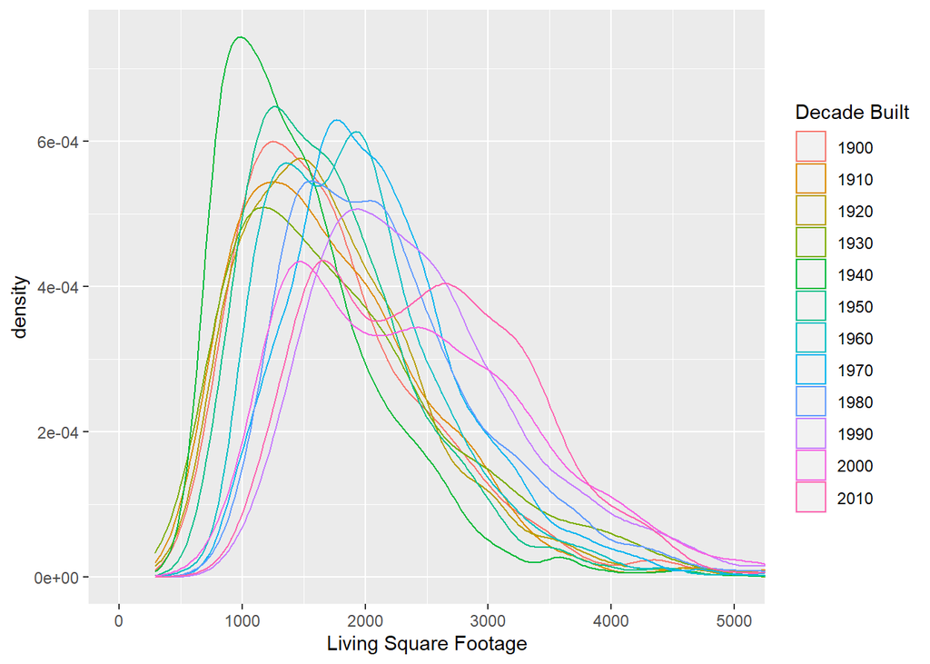

```r
#Q1 visualizations
train %>%
  ggplot(aes(x=sqft_living, color=as.factor(dec_built))) +
  geom_density()+
  labs(x='Living Square Footage', col="Decade Built")+
  coord_cartesian(xlim=c(0,5000))
```

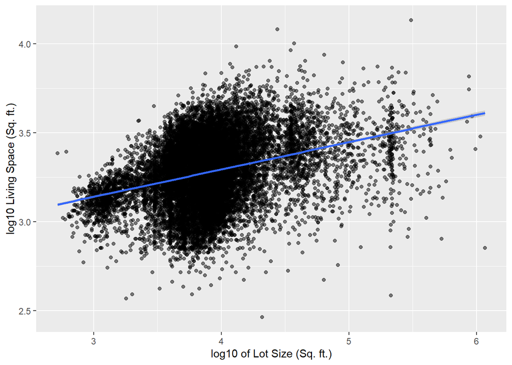

```r
train %>%
  ggplot(aes(x=log10(sqft_lot), y=log10(sqft_living))) +
  geom_point(alpha=0.5)+
  geom_smooth(method='lm')+
  labs(x='log10 of Lot Size (Sq. ft.)', y="log10 Living Space (Sq. ft.)")
```

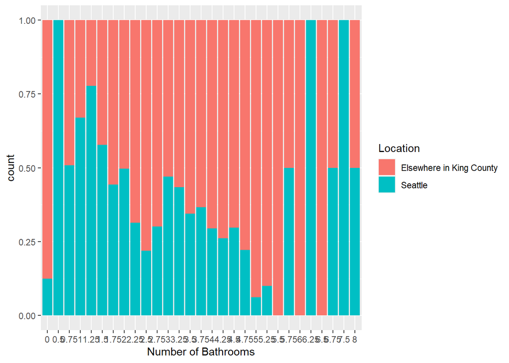

```r
# Q2 visualizations
train %>%
  ggplot(aes(x=as.factor(bathrooms), fill=Seattle)) +
  geom_bar(position = 'fill')+
  labs(x='Number of Bathrooms')+
  guides(fill=guide_legend(title="Location"))
```

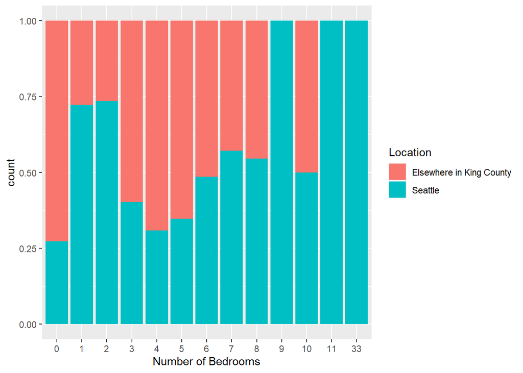

```r
train %>%
  ggplot(aes(x=as.factor(bedrooms), fill=Seattle)) +
  geom_bar(position = 'fill')+
  labs(x='Number of Bedrooms')+
  guides(fill=guide_legend(title="Location"))
```

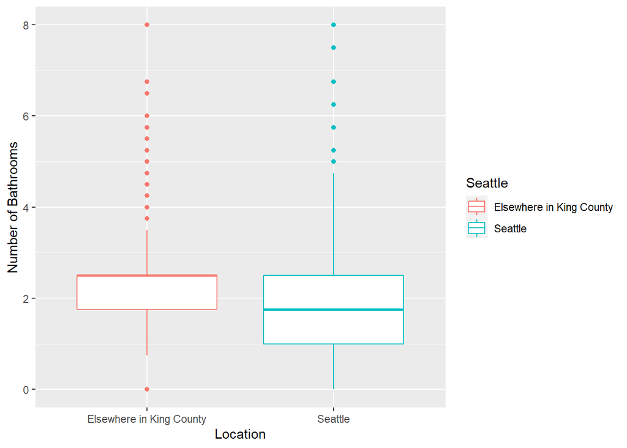

```r
train %>%
  ggplot(aes(x=Seattle, y=bathrooms, color = Seattle)) +
  geom_boxplot()+
  labs(x='Location', y="Number of Bathrooms")
```

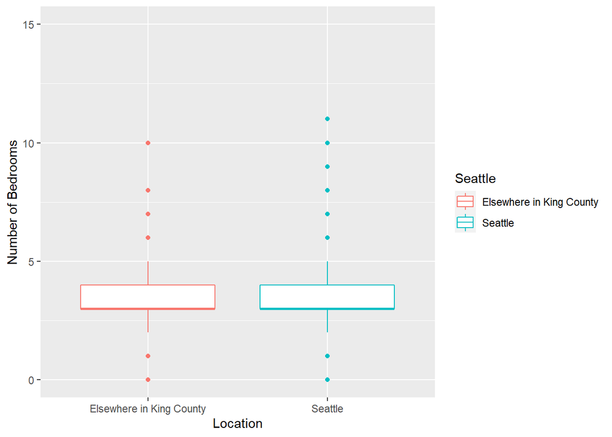

```r
train %>%
  ggplot(aes(x=Seattle, y=bedrooms, color=Seattle)) +
  geom_boxplot()+
  labs(x='Location', y="Number of Bedrooms")+
  coord_cartesian(ylim=c(0,15))
```

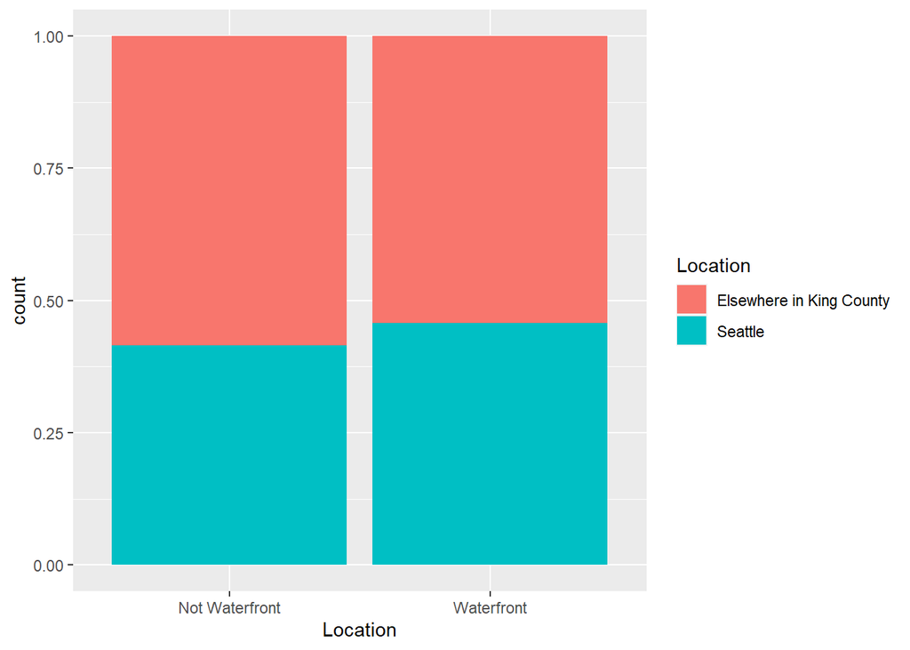

```r
train %>%
  ggplot(aes(x=waterfront, fill=Seattle)) +
  geom_bar(position = 'fill')+
  labs(x='Location') +
  guides(fill=guide_legend(title="Location"))
```

#### `zipcode` v. `sqft_living`

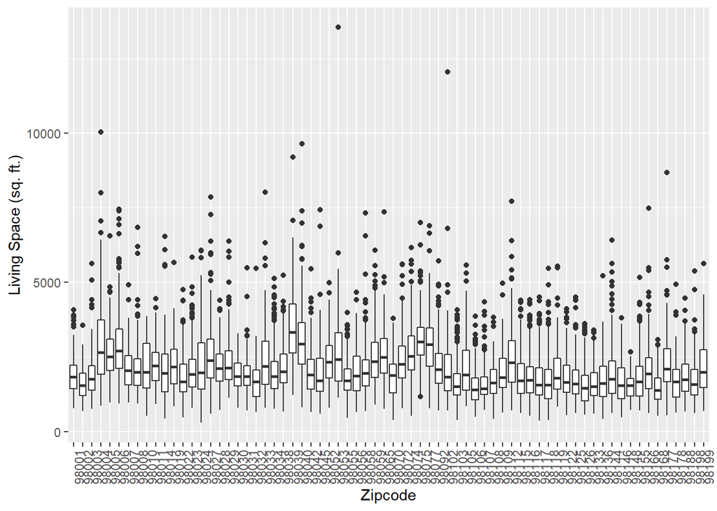

```r
ggplot(train, aes(x=as.factor(zipcode), y=sqft_living)) +
  geom_boxplot() + labs(x='Zipcode', y='Living Space (sq. ft.)') + theme(legend.position="none", axis.text.x = element_text(angle = 90))
```

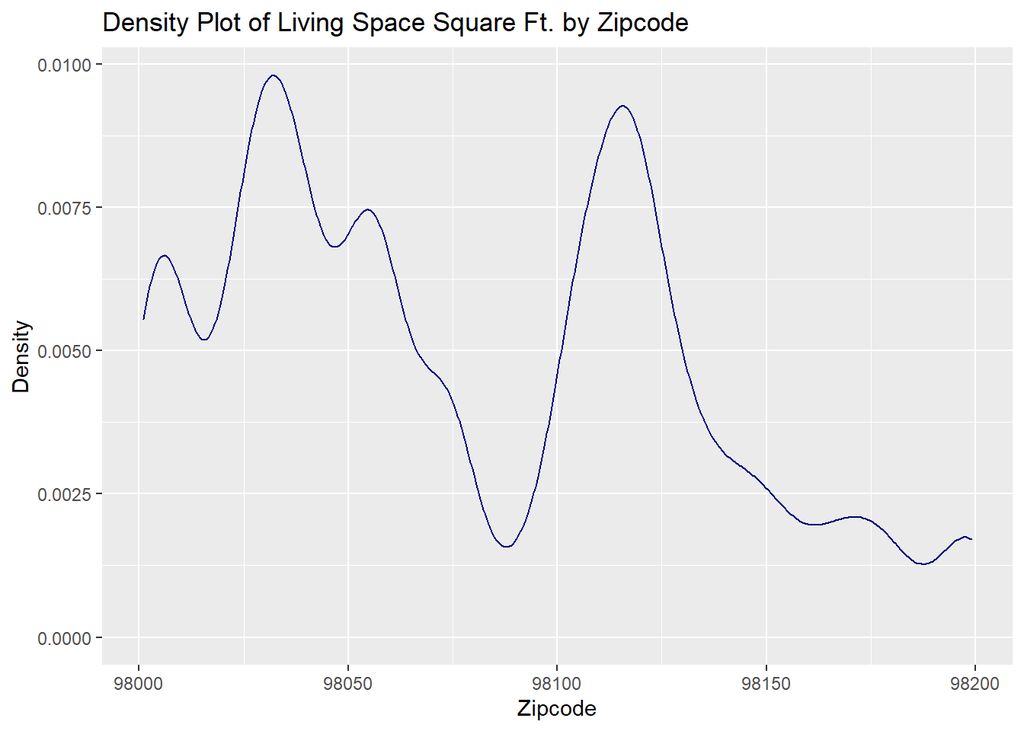

```r
# Square Footage based on Zipcode
ggplot(train, aes(x=zipcode, fill=sqft_living))+
  geom_density(color='navyblue')+
  labs(title="Density Plot of Living Space Square Ft. by Zipcode", x='Zipcode', y='Density')
```

#### `sqft_living15` v. `sqft_living`

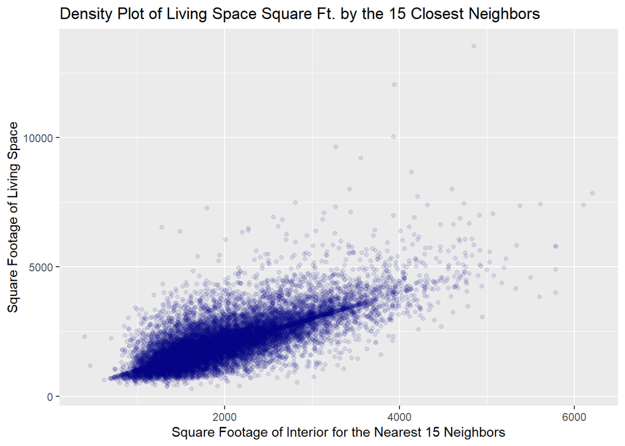

```r
# Square Footage based on the Square Footage of the 15 nearest-neighbors
ggplot(train, aes(x=sqft_living15, y=sqft_living))+
  geom_point(alpha = 0.1, color='navyblue')+
  labs(title="Density Plot of Living Space Square Ft. by the 15 Closest Neighbors", x='Square Footage of Interior for the Nearest 15 Neighbors', y='Square Footage of Living Space')
```

Looks like there’s a linear relationship between the square footage of the nearest 15 neighbors and the square footage of the home, as expected.

## Question 2 Visualizations:

#### `view` v. `Seattle`

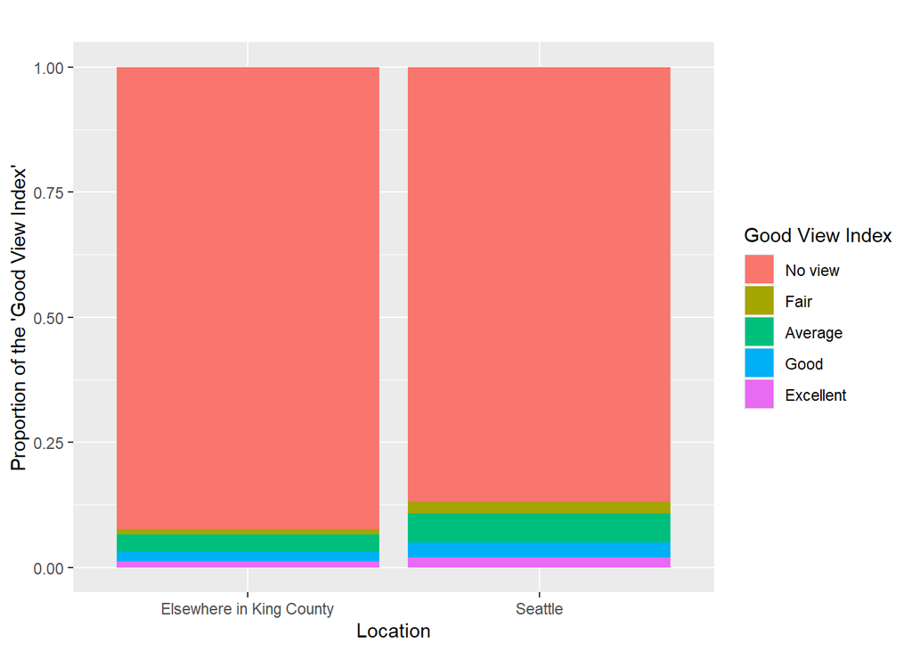

```r
# Seattle or Not based on View
ggplot(train, aes(x=as.factor(Seattle), fill=as.factor(view)))+
  geom_bar(position = "fill")+
  labs(x="Location", y="Proportion of the 'Good View Index'", title="", fill='Good View Index') + scale_x_discrete(name='Location', labels=c('1' = 'Seattle', '0' = 'Elsewhere in King County')) +  scale_fill_discrete( labels=c('0' = 'No view', '1' = 'Fair', '2' = 'Average', '3' = 'Good', '4' = 'Excellent'))
```

Seattle has a larger proportion of the good views (rated 2, 3 and 4, being highest) than elsewhere in King County, as expected. We expected this as Seattle has city views and the bay and Lake Washington (AKA coastline of the Pugen sound).

#### `view` v. `waterfront`

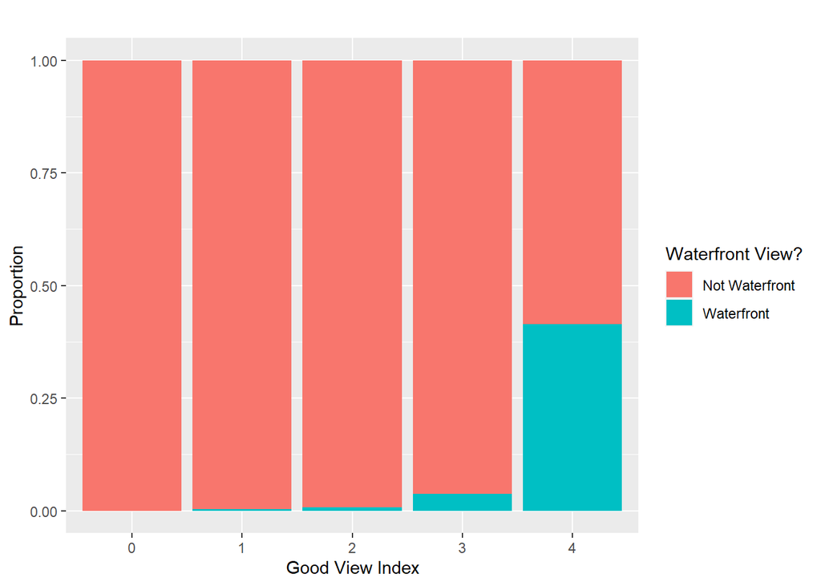

```r
ggplot(train, aes(x=as.factor(view), fill=as.factor(waterfront)))+
  geom_bar(position = "fill") + labs(x="Good View Index", y="Proportion", title="", fill='Waterfront View?') +  scale_fill_discrete( labels=c('1' = 'Yes', '0' = 'No'))
```

As expected, the Good View Index and Waterfront view are correlated, and may result in a multicolinearity issue in our model. It is highly likely we should only include one of these predictors - a hypothesis test should be conducted.

#### `sqft_lot` v. `Seattle`

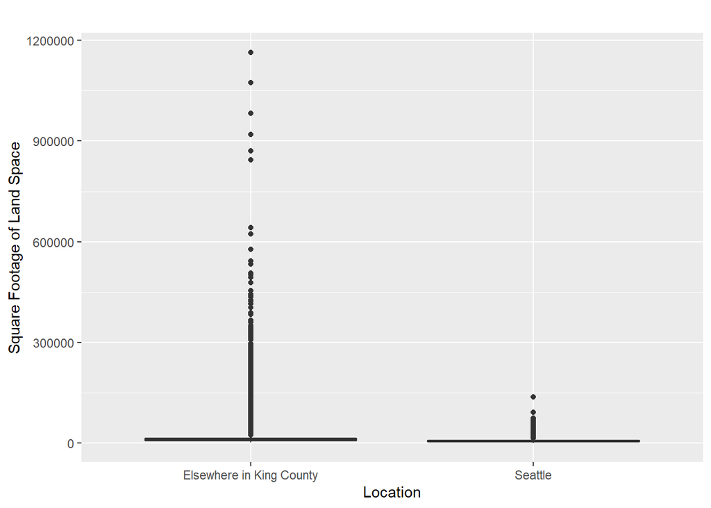

```r
# Seattle or Not based on Square Footage of the Lot
ggplot(train, aes(x=as.factor(Seattle), y=sqft_lot))+
  geom_boxplot() +
  labs(x="Location", y="Square Footage of Land Space", title="") + scale_x_discrete(name='Location', labels=c('1' = 'Seattle', '0' = 'Elsewhere in King County'))
```

Now, “zoom in” to see the median values of each.

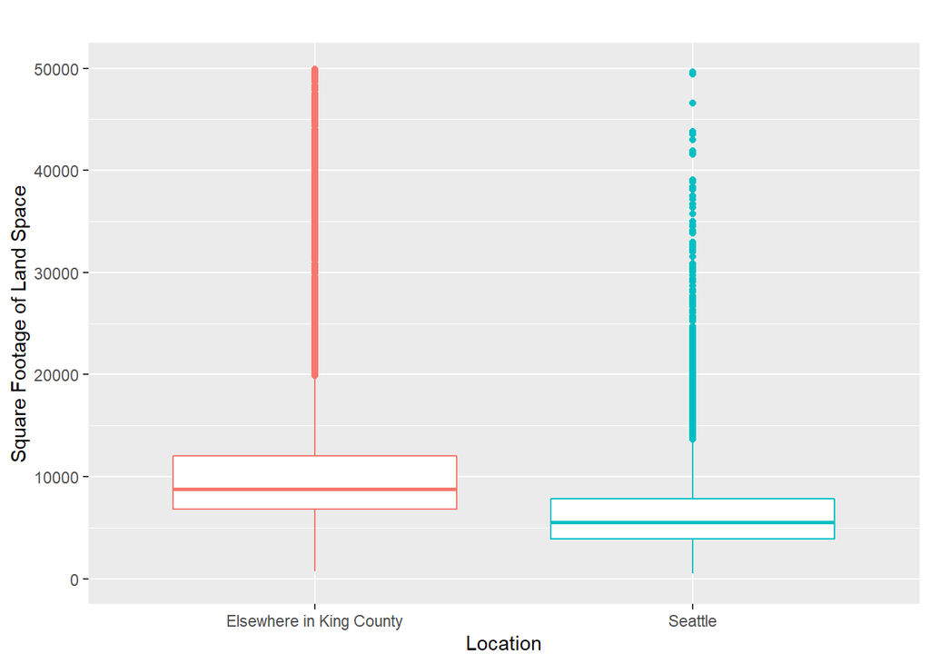

```r
ggplot(train, aes(x=as.factor(Seattle), y=sqft_lot, color=Seattle))+
  geom_boxplot() +
  labs(x="Location", y="Square Footage of Land Space", title="") + scale_x_discrete(name='Location', labels=c('1' = 'Seattle', '0' = 'Elsewhere in King County')) + ylim(0, 50000) + theme(legend.position="none")
```

Median square footage of land in Seattle is less than elsewhere in King County, as expected.

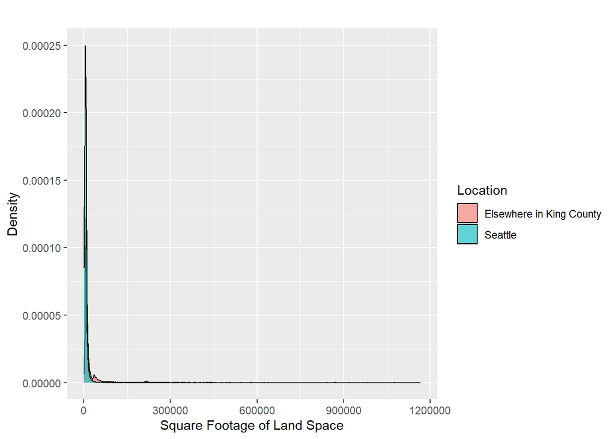

```r
# Seattle or Not based on Square Footage of the Lot
ggplot(train, aes(x=sqft_lot, fill=as.factor(Seattle)))+
  geom_density(alpha=0.6) +
  labs(x="Square Footage of Land Space", y="Density", title="") +
  scale_fill_discrete(name='Location', labels=c('1' = 'Seattle', '0' = 'Elsewhere in King County'))
```

Now, “zoom in” on the largest density portion for a better understanding.

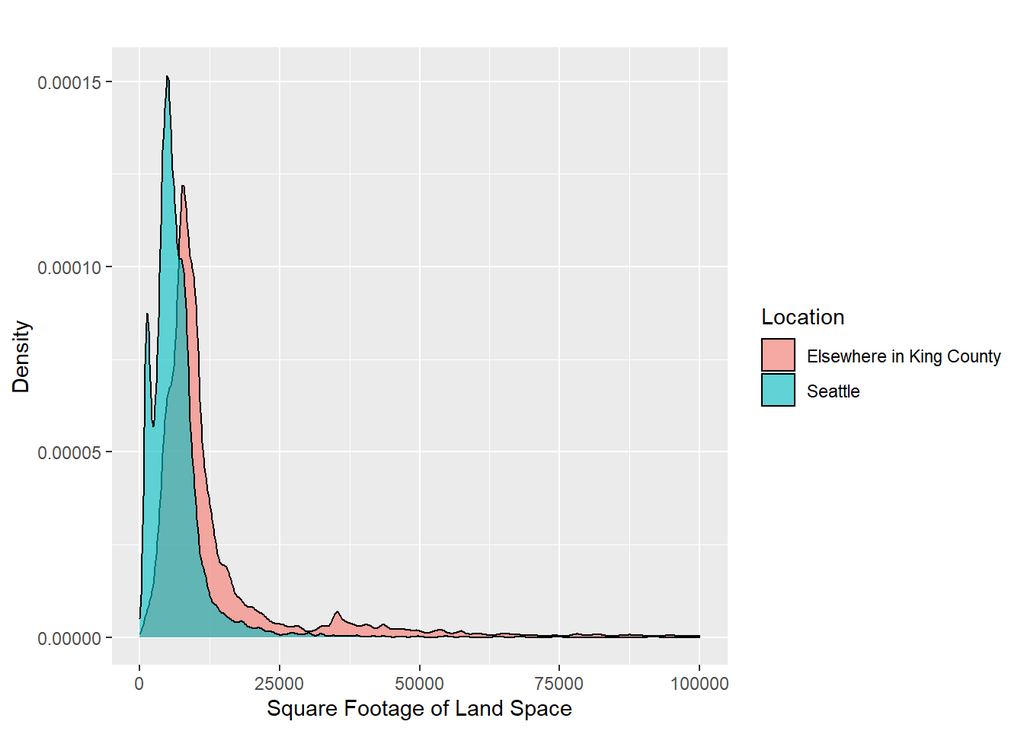

```r
ggplot(train, aes(x=sqft_lot, fill=as.factor(Seattle)))+
  geom_density(alpha=0.6) +
  labs(x="Square Footage of Land Space", y="Density", title="") +
  scale_fill_discrete(name='Location', labels=c('1' = 'Seattle', '0' = 'Elsewhere in King County')) + xlim(0, 100000)
```

Now, “zoom in” on the areas with the largest land square footage.

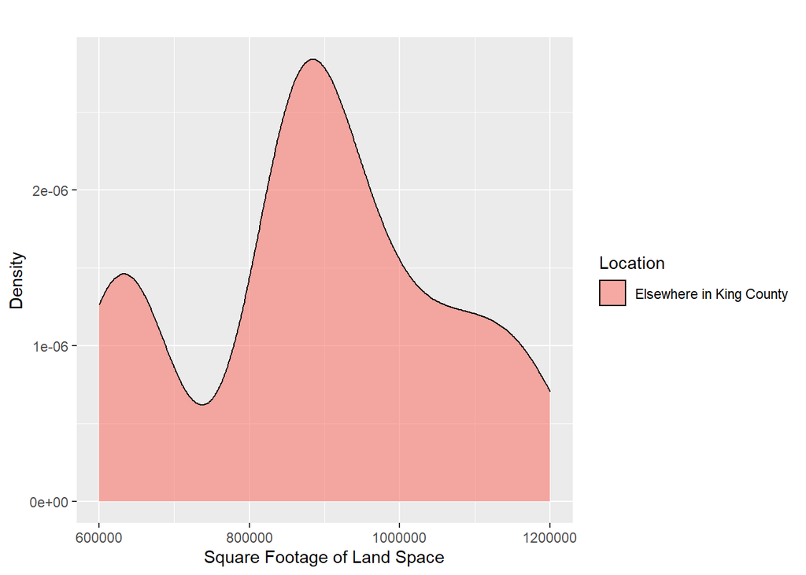

```r
ggplot(train, aes(x=sqft_lot, fill=as.factor(Seattle)))+
  geom_density(alpha=0.6) +
  labs(x="Square Footage of Land Space", y="Density", title="") +
  scale_fill_discrete(name='Location', labels=c('1' = 'Seattle', '0' = 'Elsewhere in King County')) + xlim(600000, 1200000)
```

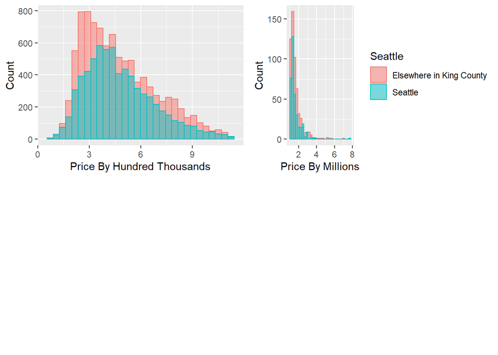

```r
upper_prices <- train %>%
  filter(price >= min(boxplot.stats(train$price)$out))
lower_prices <- train %>%
  filter(price < min(boxplot.stats(train$price)$out))
lower_hist<-ggplot(lower_prices, aes(x=price/100000, fill=Seattle, color=Seattle)) +
  geom_histogram(position="identity", alpha=0.5)+
  labs(x = "Price By Hundred Thousands",  y = "Count")+
  theme(legend.position="none")
upper_hist <- ggplot(upper_prices, aes(x=price/1000000, fill=Seattle, color=Seattle)) +
  geom_histogram(position="identity", alpha=0.5)+
  labs(x = "Price By Millions",  y = "Count")
grid.arrange(lower_hist, upper_hist,  widths=c(2,2), heights=c(3,3))
```

Square footage by location violin plot

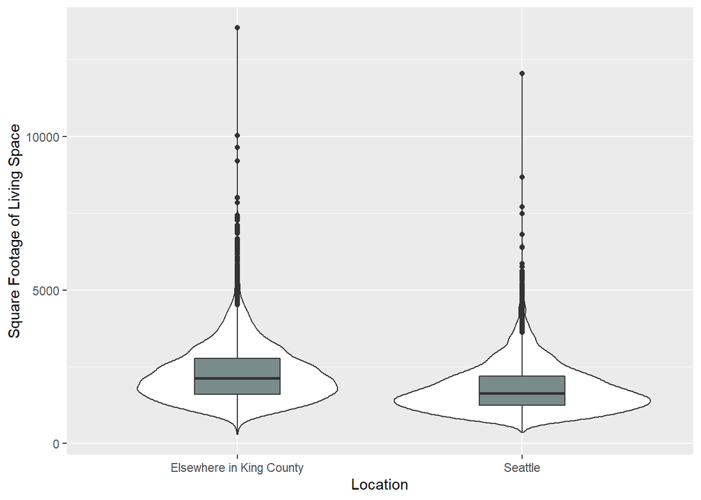

```r
ggplot(train, aes(x=Seattle, y=sqft_living))+
 geom_violin() + geom_boxplot(width = 0.3,fill = "lightcyan4") +
  labs(x = "Location",  y = "Square Footage of Living Space")
```

[figure not shown]

```r
seattle <- train %>%
  filter(Seattle==1)
town <- train %>%
  filter(Seattle == 0)

seattle_price_graph <- ggplot(seattle, aes(x=condition, y=price/1000000))+
 geom_violin() + geom_boxplot(width = 0.3,fill = "lightcyan4") +
  ylim(0,8) +
  labs(x = "Condition",  y = "Price By Millions",
       title = "Prices in Seattle by Condition")
town_price_graph <- ggplot(town, aes(x=condition, y=price/1000000))+
 geom_violin() + geom_boxplot(width = 0.3,fill = "lightcyan4") +
  ylim(0,8) +
  labs(x = "Condition",  y = "",
       title = "Prices Outside of Seattle by Condition")
grid.arrange(seattle_price_graph, town_price_graph, ncol=2, widths = c(3.5,3.5))
```

Response Variable: sqft living

#### exploring correlation matrix

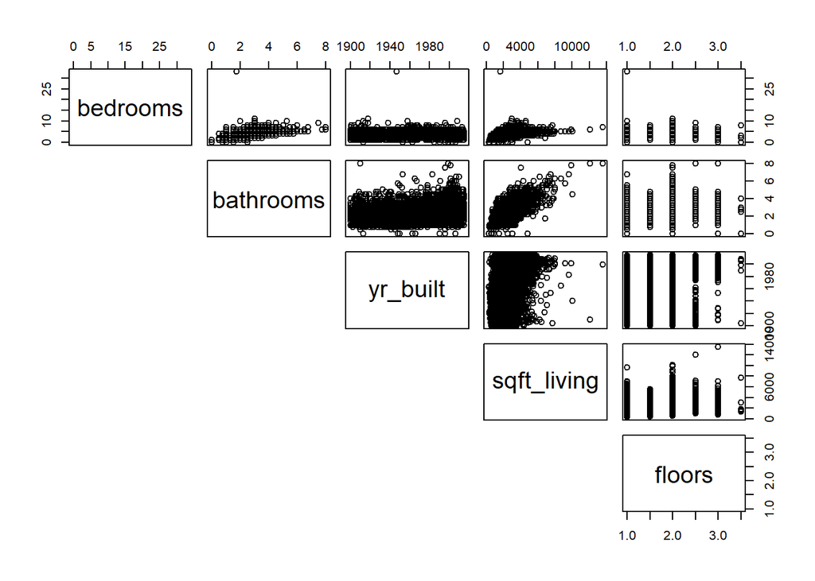

```r
myvars <- c("bedrooms", 'bathrooms','yr_built','sqft_living','floors')
newdata <- data[myvars]
pairs(newdata, lower.panel = NULL)
```

# Performing forward selection on chosen factors

```r
##intercept only model
regnull <- lm(sqft_living~1, data=train)
regfull <- lm(sqft_living~bedrooms+bathrooms+floors+waterfront+view+condition+yr_built+Seattle, data=train)
step(regnull, scope=list(lower=regnull, upper=regfull), direction="forward")
```

```
## Start:  AIC=235808.7
## sqft_living ~ 1
##
##              Df  Sum of Sq        RSS    AIC
## + bathrooms   1 8186082344 6.2965e+09 221409
## + bedrooms    1 4706755575 9.7758e+09 229015
## + floors      1 1895150073 1.2587e+10 233386
## + yr_built    1 1418477701 1.3064e+10 234028
## + view        4 1155817874 1.3327e+10 234379
## + Seattle     1  995346249 1.3487e+10 234580
## + waterfront  1  169697576 1.4313e+10 235607
## + condition   1   41598098 1.4441e+10 235761
## <none>                     1.4483e+10 235809
##
## Step:  AIC=221409
## sqft_living ~ bathrooms
##
##              Df Sum of Sq        RSS    AIC
## + bedrooms    1 678339519 5618162509 219440
## + view        4 313626635 5982875394 220534
## + Seattle     1  95770794 6200731234 221146
## + yr_built    1  84835883 6211666146 221176
## + waterfront  1  50979033 6245522995 221270
## + condition   1  22090639 6274411390 221350
## + floors      1   6178425 6290323604 221394
## <none>                    6296502028 221409
##
## Step:  AIC=219440.1
## sqft_living ~ bathrooms + bedrooms
##
##              Df Sum of Sq        RSS    AIC
## + view        4 340812676 5277349834 218366
## + waterfront  1  71345533 5546816977 219221
## + Seattle     1  63365928 5554796581 219246
## + yr_built    1  30514471 5587648038 219348
## + condition   1   3224287 5614938222 219432
## <none>                    5618162509 219440
## + floors      1     88410 5618074100 219442
##
## Step:  AIC=218366.1
```

[output cut: 30 more lines]

```
## sqft_living ~ bathrooms + bedrooms + view + Seattle + yr_built +
##     floors
##
##              Df Sum of Sq        RSS    AIC
## + condition   1   2577618 5083016855 217725
## <none>                    5085594473 217732
## + waterfront  1    164006 5085430467 217734
##
## Step:  AIC=217725.4
## sqft_living ~ bathrooms + bedrooms + view + Seattle + yr_built +
##     floors + condition
##
##              Df Sum of Sq        RSS    AIC
## <none>                    5083016855 217725
## + waterfront  1    154015 5082862839 217727
```

```
##
## Call:
## lm(formula = sqft_living ~ bathrooms + bedrooms + view + Seattle +
##     yr_built + floors + condition, data = train)
##
## Coefficients:
##    (Intercept)       bathrooms        bedrooms           view1           view2
##       6310.068         703.190         234.774         360.334         363.759
##          view3           view4  SeattleSeattle        yr_built          floors
##        518.917         805.499        -247.487          -3.311          96.697
##      condition
##        -20.370
```

# testing whether we can remove external features

Ho: reduced model (with interior features like bathrooms, bedrooms and floors) is more useful to predict sqft of the house Ha: full model with external features is more useful to predict sqft of the house

```r
result <- lm(sqft_living~bedrooms+bathrooms+floors+view+condition+yr_built+Seattle, data=train)
##fit the reduced model with just displacement
reduced <- lm(sqft_living~bathrooms+bedrooms+floors, data=train)
##perform the partial F test to see if we can
##drop the last 3 predictors
anova(reduced,result)
```

```
## Analysis of Variance Table
##
## Model 1: sqft_living ~ bathrooms + bedrooms + floors
## Model 2: sqft_living ~ bedrooms + bathrooms + floors + view + condition +
##     yr_built + Seattle
##   Res.Df        RSS Df Sum of Sq      F    Pr(>F)
## 1  17286 5618074100
## 2  17279 5083016855  7 535057245 259.84 < 2.2e-16 ***
## ---
## Signif. codes:  0 '***' 0.001 '**' 0.01 '*' 0.05 '.' 0.1 ' ' 1
```

#### Testing for Multicollinearity

```r
cor(train[,c(4,5,8,11,15)])
```

```
##             bedrooms  bathrooms     floors   condition   yr_built
## bedrooms  1.00000000  0.5107910  0.1786354  0.03276961  0.1508050
## bathrooms 0.51079103  1.0000000  0.5048679 -0.12283934  0.5041831
## floors    0.17863544  0.5048679  1.0000000 -0.26078655  0.4848145
## condition 0.03276961 -0.1228393 -0.2607865  1.00000000 -0.3586144
## yr_built  0.15080496  0.5041831  0.4848145 -0.35861441  1.0000000
```

```r
library(faraway)
vif(result)
```

```
##       bedrooms      bathrooms         floors          view1          view2
##       1.417946       2.163646       1.600805       1.010831       1.028608
##          view3          view4      condition       yr_built SeattleSeattle
##       1.029054       1.026176       1.197722       2.148837       1.403161
```

#### Levene’s test for equality of variances across levels for the categorical variables

```r
library(lawstat)
levene.test(train$sqft_living,train$view)
```

```
##
##  Modified robust Brown-Forsythe Levene-type test based on the absolute
##  deviations from the median
##
## data:  train$sqft_living
## Test Statistic = 70.694, p-value < 2.2e-16
```

```r
levene.test(train$sqft_living,train$Seattle)
```

```
##
##  Modified robust Brown-Forsythe Levene-type test based on the absolute
##  deviations from the median
##
## data:  train$sqft_living
## Test Statistic = 155.42, p-value < 2.2e-16
```

#### fitting model 1

```r
result <- lm(sqft_living~bedrooms+bathrooms+floors+view+condition+yr_built+Seattle, data=train)
summary(result)
```

```
##
## Call:
## lm(formula = sqft_living ~ bedrooms + bathrooms + floors + view +
##     condition + yr_built + Seattle, data = train)
##
## Residuals:
##     Min      1Q  Median      3Q     Max
## -6968.7  -334.2   -44.9   269.8  5545.5
##
## Coefficients:
##                 Estimate Std. Error t value Pr(>|t|)
## (Intercept)    6310.0676   409.5495   15.41  < 2e-16 ***
## bedrooms        234.7739     5.2712   44.54  < 2e-16 ***
## bathrooms       703.1899     7.8916   89.11  < 2e-16 ***
## floors           96.6969     9.6666   10.00  < 2e-16 ***
## view1           360.3339    33.3273   10.81  < 2e-16 ***
## view2           363.7591    20.2054   18.00  < 2e-16 ***
## view3           518.9167    27.5992   18.80  < 2e-16 ***
## view4           805.4992    34.4641   23.37  < 2e-16 ***
## condition       -20.3705     6.8817   -2.96  0.00308 **
## yr_built         -3.3112     0.2062  -16.06  < 2e-16 ***
## SeattleSeattle -247.4874     9.9143  -24.96  < 2e-16 ***
## ---
## Signif. codes:  0 '***' 0.001 '**' 0.01 '*' 0.05 '.' 0.1 ' ' 1
##
## Residual standard error: 542.4 on 17279 degrees of freedom
## Multiple R-squared:  0.649,  Adjusted R-squared:  0.6488
## F-statistic:  3195 on 10 and 17279 DF,  p-value: < 2.2e-16
```

#### Checking assumptions

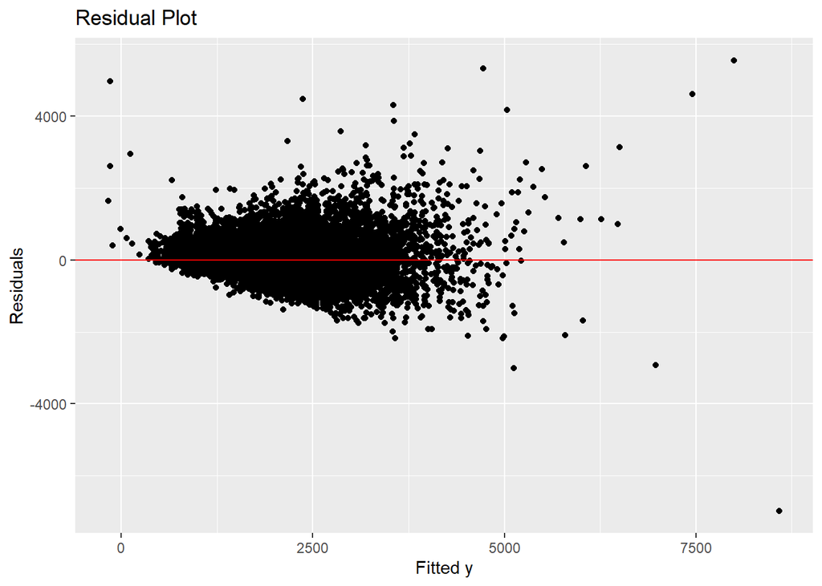

```r
library(tidyr)
##store fitted y & residuals
yhat<-result$fitted.values
res<-result$residuals
train <- train %>% drop_na(sqft_living) ##store fitted y & residuals yhat<-result$fitted.values res<-result$residuals
##add to data frame
Data<-data.frame(train,yhat,res)
ggplot(Data, aes(x=yhat,y=res))+
geom_point()+
geom_hline(yintercept=0, color="red")+
labs(x="Fitted y", y="Residuals", title="Residual Plot")
```

The residuals should be evenly scattered on both sides of the red horizontal line, as we move from left to right. We see this in the residual plot, so assumption 1 is met.

The vertical spread of the residuals should be constant as we move from left to right. The spread seems to have a fanning out pattern which makes it inconsistent. Therefore assumption 2 is violated and we might elect to transform our model.

#### boxcox to transform model

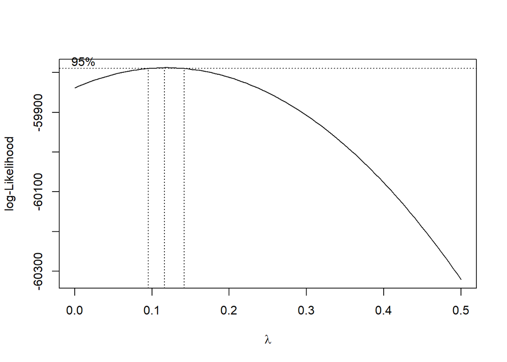

```r
library(MASS)
boxcox(result, lambda = seq(0, 0.5, 1/20))
```

#### transform by lambda = 0.1 & Check assumptions again

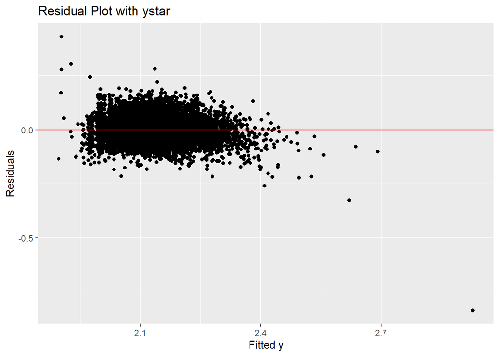

```r
ystar<-(Data$sqft_living)^0.1
Data<-data.frame(Data,ystar)
result.ystar<-lm(ystar~bedrooms+bathrooms+floors+view+condition+yr_built+Seattle, data=Data)
##store fitted y & residuals
yhat2<-result.ystar$fitted.values
res2<-result.ystar$residuals
##add to data frame
Data<-data.frame(Data,yhat2,res2)

##residual plot with ystar
ggplot(Data, aes(x=yhat2,y=res2))+
geom_point()+
geom_hline(yintercept=0, color="red")+
labs(x="Fitted y",
     y="Residuals",
title="Residual Plot with ystar")
```

## Pairwise Comparison

```r
regfull <- lm(sqft_living~bedrooms+bathrooms+floors+waterfront+view+condition+yr_built+Seattle, data=train)
summary(regfull)
```

```
##
## Call:
## lm(formula = sqft_living ~ bedrooms + bathrooms + floors + waterfront +
##     view + condition + yr_built + Seattle, data = train)
##
## Residuals:
##     Min      1Q  Median      3Q     Max
## -6973.9  -334.3   -45.1   270.1  5563.4
##
## Coefficients:
##                       Estimate Std. Error t value Pr(>|t|)
## (Intercept)          6298.5691   409.8634  15.367  < 2e-16 ***
## bedrooms              234.9432     5.2765  44.527  < 2e-16 ***
## bathrooms             703.1180     7.8924  89.088  < 2e-16 ***
## floors                 96.5117     9.6701   9.980  < 2e-16 ***
## waterfrontWaterfront   42.8972    59.2862   0.724  0.46935
## view1                 360.1425    33.3288  10.806  < 2e-16 ***
## view2                 363.4176    20.2112  17.981  < 2e-16 ***
## view3                 517.3284    27.6867  18.685  < 2e-16 ***
## view4                 787.7210    42.3263  18.611  < 2e-16 ***
## condition             -20.3316     6.8820  -2.954  0.00314 **
## yr_built               -3.3055     0.2064 -16.018  < 2e-16 ***
## SeattleSeattle       -247.1938     9.9227 -24.912  < 2e-16 ***
## ---
## Signif. codes:  0 '***' 0.001 '**' 0.01 '*' 0.05 '.' 0.1 ' ' 1
##
## Residual standard error: 542.4 on 17278 degrees of freedom
## Multiple R-squared:  0.649,  Adjusted R-squared:  0.6488
## F-statistic:  2905 on 11 and 17278 DF,  p-value: < 2.2e-16
```

```r
vcov(regfull)
```

```
##                       (Intercept)     bedrooms   bathrooms       floors
## (Intercept)          167988.00044 -367.5720605 1026.879486 1107.3378680
## bedrooms               -367.57206   27.8410421  -20.250632    1.4421641
## bathrooms              1026.87949  -20.2506320   62.289585  -25.2147369
## floors                 1107.33787    1.4421641  -25.214737   93.5113778
## waterfrontWaterfront   -942.15059   13.8716876   -5.885692  -15.1726600
## view1                  -417.51611    1.0247994  -19.018934   12.7310169
## view2                  -529.89408    2.0166687  -20.867226    4.7962694
## view3                  -619.34761    3.1069252  -31.022695    6.2086750
## view4                  -376.12147    1.6801027  -35.434276   10.3053328
## condition             -1015.10557   -1.5815442   -3.445411    6.9918095
## yr_built                -84.34018    0.1608266   -0.527374   -0.6159525
## SeattleSeattle        -1943.61239    6.4238857    2.281282  -21.5968132
##                      waterfrontWaterfront        view1        view2       view3
## (Intercept)                  -942.1505938 -417.5161130 -529.8940803 -619.347612
## bedrooms                       13.8716876    1.0247994    2.0166687    3.106925
## bathrooms                      -5.8856923  -19.0189341  -20.8672257  -31.022695
## floors                        -15.1726600   12.7310169    4.7962694    6.208675
## waterfrontWaterfront         3514.8570901  -15.6793675  -27.9803805 -130.138003
## view1                         -15.6793675 1110.8068756   28.7231994   32.138280
## view2                         -27.9803805   28.7231994  408.4912384   33.980006
## view3                        -130.1380030   32.1382799   33.9800061  766.553973
## view4                       -1456.6901294   40.0342994   47.1036529   96.551177
## condition                       3.1870646   -0.6913686   -1.5371343   -1.413611
## yr_built                        0.4615997    0.2148431    0.2787518    0.331886
## SeattleSeattle                 24.0551822  -13.9896551  -10.0376421  -11.166799
##                              view4     condition     yr_built SeattleSeattle
## (Intercept)           -376.1214743 -1015.1055666 -84.34017801  -1943.6123925
## bedrooms                 1.6801027    -1.5815442   0.16082657      6.4238857
## bathrooms              -35.4342764    -3.4454106  -0.52737404      2.2812819
## floors                  10.3053328     6.9918095  -0.61595247    -21.5968132
## waterfrontWaterfront -1456.6901294     3.1870646   0.46159968     24.0551822
## view1                   40.0342994    -0.6913686   0.21484306    -13.9896551
## view2                   47.1036529    -1.5371343   0.27875178    -10.0376421
## view3                   96.5511773    -1.4136114   0.33188598    -11.1667989
## view4                 1791.5163832    -5.8346490   0.22220454    -21.4819030
## condition               -5.8346490    47.3615073   0.43248023      8.0816479
## yr_built                 0.2222045     0.4324802   0.04258413      0.9548806
## SeattleSeattle         -21.4819030     8.0816479   0.95488057     98.4608682
```

```r
# find delta values for categorical predictors
p <- 12
n <- 17290

t.waterfront <- qt(1-(0.05/4),n-p)
t.view <- qt(1-(0.05/10),n-p)
t.Seattle <- qt(1-(0.05/4),n-p)
```

```r
# waterfront
42.8972 - t.waterfront*sqrt(3514.8570901)
```

```
## [1] -89.9987
```

```r
42.8972 + t.waterfront*sqrt(3514.8570901)
```

```
## [1] 175.7931
```

Since the interval contains 0 we can drop waterfront from the model.

```r
print("view1 & 0")
```

```
## [1] "view1 & 0"
```

```r
360.1425 - t.view*sqrt(1110.8068756)
```

```
## [1] 274.2838
```

```r
360.1425 + t.view*sqrt(1110.8068756)
```

```
## [1] 446.0012
```

```r
print("view2 & 0")
```

```
## [1] "view2 & 0"
```

```r
363.4176 - t.view*sqrt(408.4912384)
```

```
## [1] 311.3513
```

```r
363.4176 + t.view*sqrt(408.4912384)
```

```
## [1] 415.4839
```

```r
print("view3 & 0")
```

```
## [1] "view3 & 0"
```

```r
517.3284 - t.view*sqrt(766.553973)
```

```
## [1] 446.0043
```

```r
517.3284 + t.view*sqrt(766.553973)
```

```
## [1] 588.6525
```

```r
print("view4 & 0")
```

```
## [1] "view4 & 0"
```

```r
787.7210 - t.view*sqrt(1791.5163832)
```

```
## [1] 678.6836
```

```r
787.7210 + t.view*sqrt(1791.5163832)
```

```
## [1] 896.7584
```

```r
print("view1 & 2")
```

```
## [1] "view1 & 2"
```

```r
(360.1425-363.4176) - t.view*sqrt(1110.8068756-408.4912384)
```

```
## [1] -71.54531
```

```r
(360.1425-363.4176) + t.view*sqrt(1110.8068756-408.4912384)
```

```
## [1] 64.99511
```

```r
print("view1 & 3")
```

```
## [1] "view1 & 3"
```

```r
(360.1425-517.3284) - t.view*sqrt(1110.8068756-766.553973)
```

```
## [1] -204.9833
```

```r
(360.1425-517.3284) + t.view*sqrt(1110.8068756-766.553973)
```

```
## [1] -109.3885
```

```r
print("view4 & 1")
```

```
## [1] "view4 & 1"
```

```r
(787.7210-360.1425) - t.view*sqrt(1791.5163832-1110.8068756)
```

```
## [1] 360.3666
```

```r
(787.7210-360.1425) + t.view*sqrt(1791.5163832-1110.8068756)
```

```
## [1] 494.7904
```

```r
print("view2 & 3")
```

```
## [1] "view2 & 3"
```

```r
(517.3284-363.4176) - t.view*sqrt(766.553973-408.4912384)
```

```
## [1] 105.1642
```

```r
(517.3284-363.4176) + t.view*sqrt(766.553973-408.4912384)
```

```
## [1] 202.6574
```

```r
print("view4 & 2")
```

```
## [1] "view4 & 2"
```

```r
(787.7210-363.4176) - t.view*sqrt(1791.5163832-408.4912384)
```

```
## [1] 328.5002
```

```r
(787.7210-363.4176) + t.view*sqrt(1791.5163832-408.4912384)
```

```
## [1] 520.1066
```

```r
print("view4 & 3")
```

```
## [1] "view4 & 3"
```

```r
(787.7210-517.3284) - t.view*sqrt(1791.5163832-766.553973)
```

```
## [1] 187.9182
```

```r
(787.7210-517.3284) + t.view*sqrt(1791.5163832-766.553973)
```

```
## [1] 352.867
```

only the interval between view index 1 & view index 2 contains 0 - but since all others do not we should not collapse groups.

```r
-247.1938 - t.Seattle*sqrt(98.4608682)
```

```
## [1] -269.4366
```

```r
-247.1938 + t.Seattle*sqrt(98.4608682)
```

```
## [1] -224.951
```

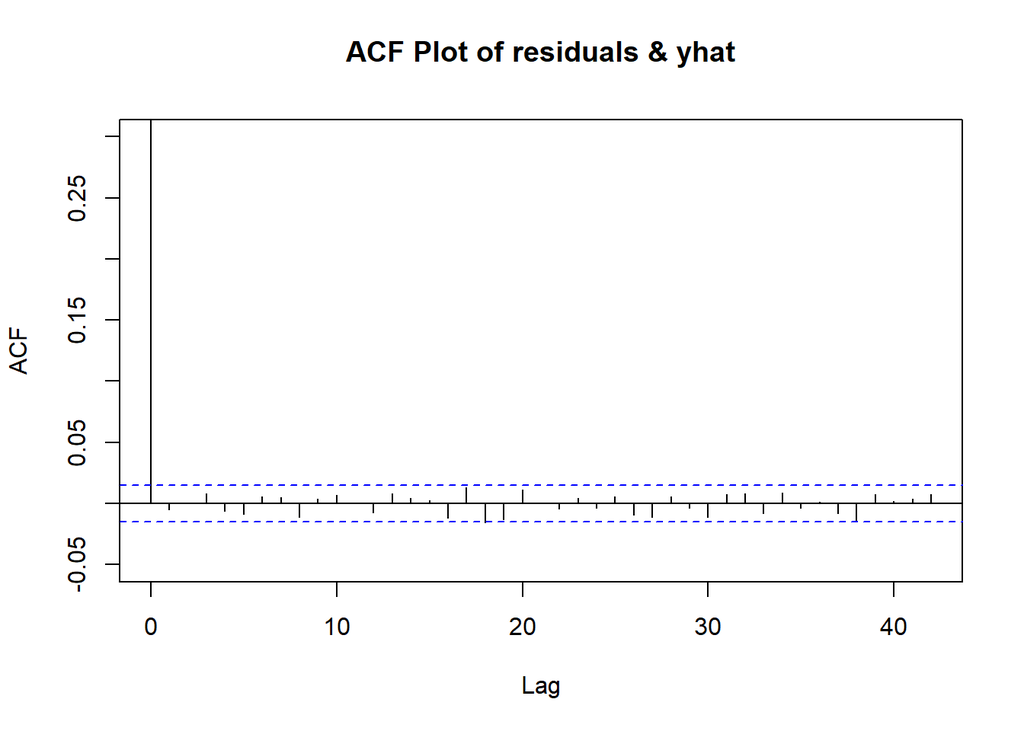

```r
acf(res2,ylim = c(-0.05,0.3),main='ACF Plot of residuals & yhat')
```

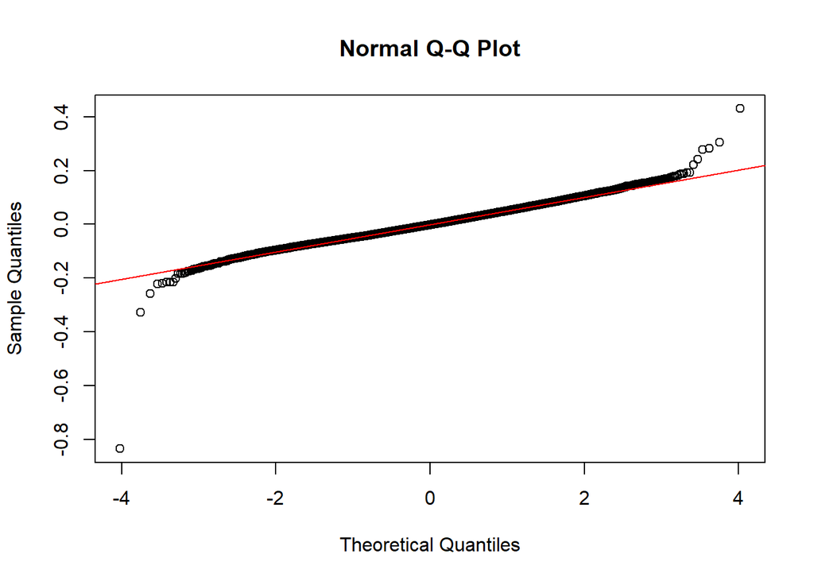

```r
qqnorm(res2)
qqline(res2, col="red")
```

The distribution with a tail will have both the ends of the Q-Q plot to deviate from the straight line and its center follows a straight line. The tail means that compared to the normal distribution there is much more data located at the extremes of the distribution and less data in the center of the distribution.

# Leverage tests

```r
lev <- lm.influence(result.ystar)$hat
# lev[lev>2*p/n]
```

```r
# Cook's distance
COOKS <- cooks.distance(result.ystar)
COOKS[COOKS>qf(0.5,p,n-p)]
```

```
##    15871
## 2.411018
```